# Практика 01 · Що таке машинне навчання

> 📖 **Теорія:** відкрий `lecture.html` у цій же теці. 📝 **Домашнє завдання:** `homework.html` · 🧪 **Тест:** `quiz.html`

Наскрізний приклад той самий, що в лекції: **дошка оголошень про продаж вживаних телефонів**. Серед оголошень є шахрайські, і їх треба відсіювати.

**Що зробимо:**

1. Зберемо синтетичну дошку оголошень — звичайний `DataFrame`
2. Напишемо фільтр шахрайства **правилами руками** й поміряємо, скільки він ловить
3. Дамо ті самі дані моделі зі `scikit-learn` і порівняємо два стовпчики чисел
4. Побудуємо крихітну регресію ціни й подивимось, що вона каже за межами даних

```python
import numpy as np
import pandas as pd
import matplotlib.pyplot as plt

rng = np.random.default_rng(42)

print("numpy   ", np.__version__)
print("pandas  ", pd.__version__)
print("генератор випадкових чисел зафіксовано: default_rng(42)")
```

```
numpy    2.5.1
pandas   2.3.3
генератор випадкових чисел зафіксовано: default_rng(42)
```

## 1. Дошка оголошень

Дані синтетичні, але побудовані за правдоподібною логікою. Спершу для кожного оголошення визначаємо **справедливу ціну** — від року випуску, обсягу памʼяті та стану. Потім вирішуємо, чи оголошення шахрайське, і залежно від цього ставимо ціну: шахрай ставить помітно нижчу, щоб привабити покупця.

Колонка `is_fraud` — це те, що колись проставив модератор. Саме вона й робить можливим навчання з учителем.

```python
N_ADS = 700
FRAUD_SHARE = 0.25                 # чверть оголошень на дошці — шахрайські

phone_models = np.array(["Galaxy A54", "iPhone 12", "Redmi Note 12", "Pixel 7"])
condition_names = np.array(["новий", "добрий", "потертий"])
condition_bonus = {"новий": 1500, "добрий": 0, "потертий": -1200}

year = rng.integers(2018, 2024, N_ADS)                 # рік випуску
memory_gb = rng.choice([64, 128, 256], N_ADS)          # обсяг памʼяті
condition = rng.choice(condition_names, N_ADS)
model_name = rng.choice(phone_models, N_ADS)

# справедлива ціна: базова вартість + надбавки. Це «правда», якої в реальних
# даних ми не бачимо — вона потрібна лише щоб згенерувати правдоподібні ціни
fair_price = (2900
              + 1750 * (year - 2018)
              + 21 * (memory_gb - 64)
              + np.array([condition_bonus[c] for c in condition])
              + rng.normal(0, 500, N_ADS))

is_fraud = (rng.random(N_ADS) < FRAUD_SHARE).astype(int)

print(f"усього оголошень : {N_ADS}")
print(f"з них шахрайських: {is_fraud.sum()}")
print(f"чесних           : {N_ADS - is_fraud.sum()}")
```

```
усього оголошень : 700
з них шахрайських: 173
чесних           : 527
```

Тепер ставимо ціну й вік акаунта продавця. Шахрай робить дві речі: ставить ціну помітно нижчу за справедливу і публікує оголошення зі свіжого акаунта. Але робить це **не завжди** — інакше задача розвʼязувалась би одним `if`.

```python
# шахрайська знижка глибока, чесний торг — дрібний
discount = np.where(is_fraud == 1,
                    rng.uniform(0.35, 0.95, N_ADS),
                    rng.uniform(0.85, 1.15, N_ADS))
price = np.round(fair_price * discount, -1)            # округлюємо до десятків

# вік акаунта: у шахраїв здебільшого свіжий, але трапляються й старі
account_age_days = np.where(is_fraud == 1,
                            rng.integers(0, 60, N_ADS),
                            rng.integers(0, 400, N_ADS))

ads = pd.DataFrame({
    "model": model_name,
    "year": year,
    "condition": condition,
    "memory_gb": memory_gb,
    "account_age_days": account_age_days,
    "price": price,
    "is_fraud": is_fraud,
})

print(ads.head(8).to_string(index=False))
```

```
        model  year condition  memory_gb  account_age_days   price  is_fraud
      Pixel 7  2018  потертий        128               207  3120.0         0
Redmi Note 12  2022     новий        128               289 13920.0         0
   Galaxy A54  2021     новий         64                32  3950.0         1
   Galaxy A54  2020     новий         64                 9  9480.0         0
      Pixel 7  2020     новий         64               147  8190.0         0
    iPhone 12  2023     новий        128                12 11250.0         1
      Pixel 7  2018    добрий         64               258  2670.0         0
   Galaxy A54  2022  потертий        128                41  3930.0         1
```

Одна ознака нам ще потрібна, і її в таблиці немає: **наскільки ціна нижча за ринкову**. Ринкову ціну ми не знаємо, але можемо оцінити її з самих даних — як медіанну ціну серед оголошень із тим самим роком і обсягом памʼяті.

Медіана тут краща за середнє: шахрайські ціни її майже не зсувають.

```python
# transform повертає значення для кожного рядка, а не по одному на групу —
# саме тому результат одразу лягає в нову колонку
market_price = ads.groupby(["year", "memory_gb"])["price"].transform("median")
ads["price_ratio"] = ads["price"] / market_price

print("ціна відносно ринкової, медіана по групах:")
print(ads.groupby("is_fraud")["price_ratio"].describe()[["count", "mean", "min", "max"]])
```

```
ціна відносно ринкової, медіана по групах:
          count      mean       min       max
is_fraud
0         527.0  1.057138  0.207746  1.978673
1         173.0  0.679042  0.257042  1.401408
```

Подивимось на дві ознаки очима — це та сама картинка, що в лекції.

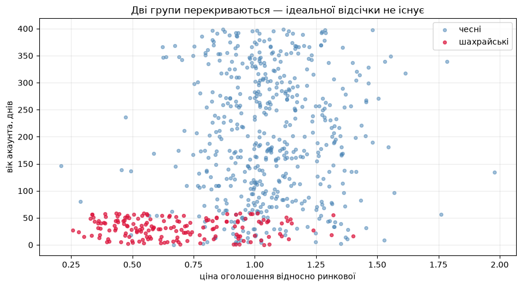

```
шахрайські тиснуться вліво-вниз, але не всі — саме тут і буде помилка
```

```python
fig, ax = plt.subplots(figsize=(9, 5))

honest = ads[ads["is_fraud"] == 0]
fraud = ads[ads["is_fraud"] == 1]
ax.scatter(honest["price_ratio"], honest["account_age_days"],
           s=16, alpha=0.5, color="steelblue", label="чесні")
ax.scatter(fraud["price_ratio"], fraud["account_age_days"],
           s=16, alpha=0.7, color="crimson", label="шахрайські")

ax.set_xlabel("ціна оголошення відносно ринкової")
ax.set_ylabel("вік акаунта, днів")
ax.set_title("Дві групи перекриваються — ідеальної відсічки не існує")
ax.legend()
ax.grid(alpha=0.25)
plt.tight_layout()
plt.show()

print("шахрайські тиснуться вліво-вниз, але не всі — саме тут і буде помилка")
```

## 2. Фільтр правилами руками

Спершу зробимо так, як робили б без жодного машинного навчання: подивимось на картинку, помітимо закономірність і напишемо дві умови.

```python
def rule_filter(table):
    """Позначає підозрілі оголошення двома написаними руками правилами."""
    too_cheap = table["price_ratio"] < 0.60          # ціна нижча за 60 % ринкової
    too_new = table["account_age_days"] < 7          # акаунту менше тижня
    return (too_cheap | too_new).astype(int)


flagged_by_rules = rule_filter(ads)

print(f"правила позначили : {flagged_by_rules.sum()} оголошень")
print(f"насправді шахрайських: {ads['is_fraud'].sum()}")
```

```
правила позначили : 111 оголошень
насправді шахрайських: 173
```

Число позначених саме по собі нічого не каже. Важливо інше: **скільки з них справді шахрайські** і **скільки чесних продавців ми образили**. Розкладемо на три числа руками, самими логічними масками.

```python
def count_hits(truth, flags):
    """Три числа, з яких складається будь-яка розмова про якість фільтра."""
    caught = int(((flags == 1) & (truth == 1)).sum())        # спіймані шахраї
    false_alarms = int(((flags == 1) & (truth == 0)).sum())  # ображені чесні
    missed = int(((flags == 0) & (truth == 1)).sum())        # пропущені шахраї
    return caught, false_alarms, missed


caught, false_alarms, missed = count_hits(ads["is_fraud"], flagged_by_rules)

print(f"спіймано шахраїв : {caught} з {ads['is_fraud'].sum()}")
print(f"хибних тривог    : {false_alarms}")
print(f"пропущено        : {missed}")
```

```
спіймано шахраїв : 92 з 173
хибних тривог    : 19
пропущено        : 81
```

## 3. Перевірка: наші числа = бібліотечні

Ті самі величини бібліотека називає **precision** (яка частка позначених справді шахрайська) і **recall** (яку частку шахраїв ми спіймали). Порахуємо їх із наших трьох чисел і звіримо зі `sklearn` — щоб побачити, що всередині немає магії.

```python
from sklearn.metrics import precision_score, recall_score

our_precision = caught / (caught + false_alarms)
our_recall = caught / (caught + missed)

sk_precision = precision_score(ads["is_fraud"], flagged_by_rules)
sk_recall = recall_score(ads["is_fraud"], flagged_by_rules)

print(f"precision: наша {our_precision:.4f}   sklearn {sk_precision:.4f}")
print(f"recall   : наша {our_recall:.4f}   sklearn {sk_recall:.4f}")

assert np.allclose([our_precision, our_recall], [sk_precision, sk_recall]), "розрахунок розійшовся!"
print("✅ збігається")
```

```
precision: наша 0.8288   sklearn 0.8288
recall   : наша 0.5318   sklearn 0.5318
✅ збігається
```

## 4. Ті самі дані, але вчимо на прикладах

Тепер жодного написаного правила. Даємо моделі дві ознаки й колонку відповідей — і нехай межу шукає сама.

Дані ділимо на дві частини: на одній модель вчиться, на другій ми її перевіряємо. Якість завжди міряють на прикладах, яких модель не бачила, — інакше ми виміряємо не вміння, а памʼять.

```python
from sklearn.model_selection import train_test_split
from sklearn.linear_model import LogisticRegression
from sklearn.preprocessing import StandardScaler
from sklearn.pipeline import make_pipeline

features = ["price_ratio", "account_age_days"]
X = ads[features]
y = ads["is_fraud"]

X_train, X_test, y_train, y_test = train_test_split(
    X, y, test_size=0.3, random_state=42, stratify=y)

# StandardScaler зводить ознаки до одного масштабу: вік акаунта міряється
# сотнями, а відношення цін — одиницями, і без цього оптимізація йде важче
fraud_model = make_pipeline(StandardScaler(), LogisticRegression())
fraud_model.fit(X_train, y_train)

print(f"навчальна вибірка: {len(X_train)} оголошень")
print(f"тестова вибірка  : {len(X_test)} оголошень")
print("модель навчена")
```

```
навчальна вибірка: 490 оголошень
тестова вибірка  : 210 оголошень
модель навчена
```

Порівнюємо чесно: обидва підходи міряємо **на одній і тій самій тестовій вибірці**, якої модель не бачила.

```python
rules_on_test = rule_filter(ads.loc[X_test.index])
model_on_test = fraud_model.predict(X_test)

rules_hits = count_hits(y_test, rules_on_test)
model_hits = count_hits(y_test, model_on_test)

comparison = pd.DataFrame(
    [rules_hits, model_hits],
    index=["правила руками", "модель"],
    columns=["спіймано", "хибних тривог", "пропущено"])

print(f"у тестовій вибірці шахраїв: {int(y_test.sum())}\n")
print(comparison.to_string())
```

```
у тестовій вибірці шахраїв: 52

                спіймано  хибних тривог  пропущено
правила руками        35              6         17
модель                49              9          3
```

Що саме «вивчила» модель? Три числа: два коефіцієнти й вільний член. Це і є те саме «правило», яке ми не писали. Знак коефіцієнта читається просто: чим більша ціна відносно ринкової, тим **нижча** оцінка шахрайства; чим старший акаунт — теж нижча.

```python
logreg = fraud_model.named_steps["logisticregression"]

print("вільний член :", round(float(logreg.intercept_[0]), 4))
for name, weight in zip(features, logreg.coef_[0]):
    print(f"вага {name:<20}: {weight:+.4f}")

print("\nусе правило моделі вміщується в три числа")
```

```
вільний член : -3.9105
вага price_ratio         : -1.2821
вага account_age_days    : -3.7556

усе правило моделі вміщується в три числа
```

І ще одна перевірка «немає магії»: порахуємо оцінку моделі вручну за формулою логістичної регресії й звіримо з тим, що видає `predict_proba`.

Формула така: беремо зважену суму ознак, додаємо вільний член і пропускаємо результат через сигмоїду — функцію, яка перетворює будь-яке число на значення від 0 до 1.

```python
scaler = fraud_model.named_steps["standardscaler"]
X_test_scaled = scaler.transform(X_test)

# зважена сума ознак плюс вільний член
linear_part = X_test_scaled @ logreg.coef_[0] + logreg.intercept_[0]
our_proba = 1 / (1 + np.exp(-linear_part))              # сигмоїда

sk_proba = fraud_model.predict_proba(X_test)[:, 1]

print(f"наші перші три оцінки   : {np.round(our_proba[:3], 6)}")
print(f"sklearn перші три оцінки: {np.round(sk_proba[:3], 6)}")

assert np.allclose(our_proba, sk_proba), "розрахунок розійшовся!"
print("✅ збігається")
```

```
наші перші три оцінки   : [0.577057 0.379083 0.126662]
sklearn перші три оцінки: [0.577057 0.379083 0.126662]
✅ збігається
```

## 5. Крихітна регресія ціни

Другий тип задачі з тієї самої таблиці: передбачити не мітку, а **число**. Вчимося на чесних оголошеннях — шахрайські ціни зіпсували б орієнтир.

```python
from sklearn.linear_model import LinearRegression

honest_ads = ads[ads["is_fraud"] == 0]

price_features = ["year", "memory_gb"]
price_model = LinearRegression()
price_model.fit(honest_ads[price_features], honest_ads["price"])

print(f"надбавка за рік випуску   : {price_model.coef_[0]:8.1f} грн")
print(f"надбавка за 1 ГБ памʼяті  : {price_model.coef_[1]:8.1f} грн")
print(f"R² на навчальних даних    : {price_model.score(honest_ads[price_features], honest_ads['price']):.3f}")
```

```
надбавка за рік випуску   :   1727.4 грн
надбавка за 1 ГБ памʼяті  :     21.5 грн
R² на навчальних даних    : 0.844
```

Ще раз переконаємось, що всередині `predict` — звичайне множення й додавання.

```python
sample = honest_ads[price_features].head(5)

our_prediction = sample.values @ price_model.coef_ + price_model.intercept_
sk_prediction = price_model.predict(sample)

print("наш прогноз    :", np.round(our_prediction, 2))
print("sklearn прогноз:", np.round(sk_prediction, 2))

assert np.allclose(our_prediction, sk_prediction), "розрахунок розійшовся!"
print("✅ збігається")
```

```
наш прогноз    : [ 4408.73 11318.23  6488.89  6488.89  3034.14]
sklearn прогноз: [ 4408.73 11318.23  6488.89  6488.89  3034.14]
✅ збігається
```

## 6. Що модель відповість за межами даних

Модель бачила телефони 2018–2023 років із памʼяттю 64, 128 і 256 ГБ. Спитаймо її про те, чого вона не бачила ніколи, і подивимось, чи попередить вона нас хоч якось.

```python
queries = pd.DataFrame({"year": [2021, 2018, 2046, 2004],
                        "memory_gb": [128, 256, 1024, 32]})
queries["прогноз, грн"] = np.round(price_model.predict(queries)).astype(int)

# скільки схожих оголошень модель узагалі бачила: той самий обсяг памʼяті
# і рік у межах ±1. Це те, чого модель ніколи не рахує сама
similar = []
for _, q in queries.iterrows():
    same = ((honest_ads["memory_gb"] == q["memory_gb"])
            & (honest_ads["year"].sub(q["year"]).abs() <= 1))
    similar.append(int(same.sum()))
queries["схожих у даних"] = similar

print(queries.to_string(index=False))

train_r2 = price_model.score(honest_ads[price_features], honest_ads["price"])
print(f"\nR² на навчанні: {train_r2:.3f} — те саме число для всіх чотирьох рядків.")
print("Метрика якості міряє минулі приклади й про ці запити не знає нічого.")
```

```
 year  memory_gb  прогноз, грн  схожих у даних
 2021        128          9591              90
 2018        256          7158              64
 2046       1024         72019               0
 2004         32        -21836               0

R² на навчанні: 0.844 — те саме число для всіх чотирьох рядків.
Метрика якості міряє минулі приклади й про ці запити не знає нічого.
```

Останні два рядки — те, заради чого вся ця практика. Модель не сказала «не знаю»: вона порахувала формулу й видала числа. Одне з них відʼємне, друге завелике для вживаного телефона. Схожих прикладів у даних — нуль, і побачити це мусили ми, а не вона.

Намалюймо це.

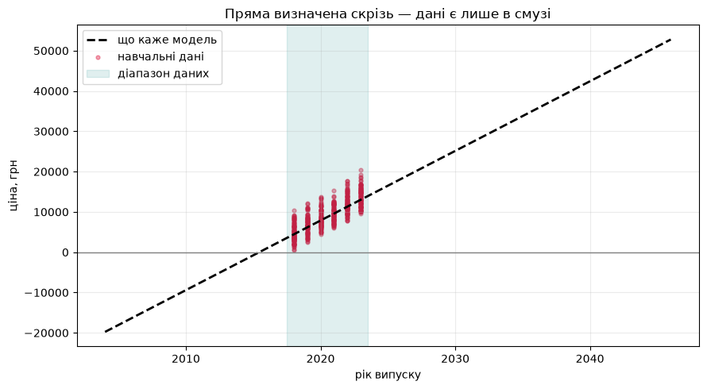

```
формула не має країв — а дані мають
```

```python
fig, ax = plt.subplots(figsize=(9, 5))

year_grid = np.arange(2004, 2047)
line = pd.DataFrame({"year": year_grid, "memory_gb": 128})
ax.plot(year_grid, price_model.predict(line), color="black", ls="--",
        lw=2, label="що каже модель")
ax.scatter(honest_ads["year"], honest_ads["price"], s=12, alpha=0.4,
           color="crimson", label="навчальні дані")
ax.axvspan(2017.5, 2023.5, color="teal", alpha=0.12, label="діапазон даних")
ax.axhline(0, color="gray", lw=1)

ax.set_xlabel("рік випуску")
ax.set_ylabel("ціна, грн")
ax.set_title("Пряма визначена скрізь — дані є лише в смузі")
ax.legend()
ax.grid(alpha=0.25)
plt.tight_layout()
plt.show()

print("формула не має країв — а дані мають")
```

## 7. Підсумок

|  | правила руками | модель |
| --- | --- | --- |
| звідки береться правило | з твоєї голови | з прикладів у даних |
| скільки часу на оновлення | нарада й реліз | перенавчання за хвилини |
| чи можна пояснити рішення | так, це `if` | лише через ваги |
| що робить поза даними | нічого не робить | впевнено вигадує |

Обидва підходи мають межу. Правила ламаються, коли їх стає забагато; модель ламається, коли даних мало або питання виходить за їхні межі.

## Завдання

### 🟢 Рівень 1

Додай до `rule_filter` третє правило — наприклад, «ціна нижча за 80 % ринкової **і** акаунту менше 30 днів» — і поміряй усі три числа знову на тестовій вибірці.

**Зроблено, якщо:** ти назвав, яке з трьох чисел покращилось, а яке погіршилось, і пояснив одним реченням чому.

### 🟡 Рівень 2

Додай моделі третю ознаку — `memory_gb` — і перевір, чи стало краще. Порівняй `count_hits` до і після на **тій самій** тестовій вибірці.

**Зроблено, якщо:** є таблиця з двома рядками (дві ознаки / три ознаки) і висновок, чи допомогла нова ознака. Якщо не допомогла — поясни, чому обсяг памʼяті нічого не каже про шахрайство.

### 🔴 Рівень 3

Змоделюй упереджені дані. Додай колонку `city` з двома значеннями і зроби так, щоб модератор **позначав** шахрайство в одному місті вдвічі частіше за однакової поведінки продавців. Навчи модель із цією колонкою серед ознак.

**Зроблено, якщо:** ти показав числами, що модель позначає оголошення з цього міста частіше, ніж вони насправді бувають шахрайськими, і назвав, звідки взялась ця різниця.